# TaskB1

zerofrom

2024-11-25

## B.1

### (1) Value of a

Considering chat $x$ follows the probability density function:

$$p_{\lambda}(x)= \begin{cases}a e^{-\lambda(x-b)} & \text { if } x
\geqslant b, \tag{1}\\ 0 & \text { if } x<b,\end{cases}$$

The probability density function $p_{\lambda}(x)$ must follows:

$$\begin{equation*}
\int_{-\infty}^{\infty} p_{\lambda}(x) d x=1 \tag{2}
\end{equation*}$$

Since $p_{\lambda}(x)=0$ when $x<b$, it follows that:

$$\begin{equation*}
\int_{b}^{\infty} p_{\lambda}(x) d x=1 \tag{3}
\end{equation*}$$

Replacing expression (1) into expression (3) yields:

$$\begin{equation*}
\int_{b}^{\infty} a e^{-\lambda(x-b)} d x=1 \tag{4}
\end{equation*}$$

Assuming that $u=x-b$, it can be obtained that:

$$\begin{equation*}
x=u+b, d x=d u \tag{5}
\end{equation*}$$

Assuming that $x=b$, then $u=0$, therefore the upper and lower limits of integration become $0 \rightarrow \infty$, substituting expression $(s)$ :

$$\begin{equation*}
\int_{0}^{\infty} a e^{-\lambda u} d u=1 \tag{6}
\end{equation*}$$

Using the exponential integration formula:

$$\begin{equation*}
\int_{0}^{\infty} e^{-a u} d u=\frac{1}{a} \tag{7}
\end{equation*}$$

Thus:

$$\begin{equation*}
a \cdot \frac{1}{\lambda}=1 \tag{8}
\end{equation*}$$

#### (2) i) Population Mean $E[X]$ :

From the definition of the mean, there is:

$$\begin{equation*}
E[x]=\int_{-\infty}^{\infty} x \cdot p_{\lambda}(x) d x \tag{1}
\end{equation*}$$

Replacing $p_{\lambda}(x)$ and $a=\lambda$ :

$$\begin{equation*}
E[x]=\int_{b}^{\infty} x \cdot \lambda e^{-\lambda(x-b)} d x \tag{2}
\end{equation*}$$

Assuming $u=x-b$, then $x=u+b$, and $d x=d u$ :

$$\begin{align*}
E[X] &= \int_{0}^{\infty}(u + b) \cdot \lambda e^{-\lambda u} \, du
\\
&= \lambda \cdot \int_{0}^{\infty} u e^{-\lambda u} \, du +
\lambda b \int_{0}^{\infty} e^{-\lambda u} \, du \tag{3}
\end{align*}$$

Integral formula for exponential functions:

$$\begin{equation*}
\int_{0}^{\infty} e^{-a x} d x=\frac{1}{a}, \int_{0}^{\infty} x e^{-a x}
d x=\frac{1}{a^{2}} \tag{4}
\end{equation*}$$

Replacing expression (t) into expression (3), there is:

$$\begin{aligned}
E[x] & =\lambda \cdot \frac{1}{\lambda^{2}}+\lambda b \cdot
\frac{1}{\lambda} \\
& =\frac{1}{\lambda}+b
\end{aligned}$$

### In conclusion, the population mean $E[x]=\frac{1}{\lambda}+b$.

#### ii) Standard Deviation $\sigma x$ :

The standard deviation formula:

$$\begin{equation*}
\sigma
x=\sqrt{\operatorname{Var}(x)}=\sqrt{E\left[x^{2}\right]-(E[x])^{2}}
\tag{1}
\end{equation*}$$

From the derivation of $E[x]$, it follows that:

$$E[x]=\frac{1}{\lambda}+b \tag{2}$$

The formula for $E\left[x^{2}\right]$ is:

$$\begin{equation*}
E\left[x^{2}\right]=\int_{b}^{\infty} x^{2} \cdot p_{\lambda}(x) d x
\tag{3}
\end{equation*}$$

Substituting $P_{\lambda}(x)$ :

$$\begin{equation*}
E\left[x^{2}\right]=\int_{b}^{\infty} x^{2} \cdot \lambda
e^{-\lambda(x-b)} d x \tag{4}
\end{equation*}$$

Assuming $u=x-b$. then $x=u+b$, and $d x=d u$ :

$$\begin{align*}
E\left[x^{2}\right]= & \int_{0}^{\infty}(u+b)^{2} \cdot \lambda
e^{-\lambda u} d u \\
= & \lambda \int_{0}^{\infty}\left(u^{2}+2 b u+b^{2}\right) \cdot
e^{-\lambda u} d u \\
= & \lambda \int_{0}^{\infty} u^{2} e^{-\lambda u} d u+2 \lambda b
\int_{0}^{\infty} u e^{-\lambda u} d u +\lambda b^{2} \int_{0}^{\infty}
e^{-\lambda u} d u \quad \tag{5}
\end{align*}$$

Integrals formula for exponential functions:

$$\begin{align*}
& \int_{0}^{\infty} e^{-a x} d x=\frac{1}{a} \\
& \int_{0}^{\infty} x e^{-a x} d x=\frac{1}{a^{2}} \\
& \int_{0}^{\infty} x^{2} e^{-a x} d x=\frac{2}{a^{3}} \tag{6}
\end{align*}$$

Replacing formulas (6) into expression (5), there is:

$$\begin{align*}
E\left[x^{2}\right] & =\lambda \cdot \frac{2}{\lambda^{3}}+2 \lambda
b \cdot \frac{1}{\lambda^{2}}+\lambda b^{2} \cdot \frac{1}{\lambda} \\
& =\frac{2}{\lambda^{2}}+\frac{2 b}{\lambda}+b^{2} \tag{7}
\end{align*}$$

Replacing expression (2) and (7) into expression (1):

$$\begin{align*}
\sigma_{x} & =\sqrt{\left(\frac{2}{\lambda^{2}}+\frac{2
b}{\lambda}+b^{2}\right)-\left(\frac{1}{\lambda}+b\right)^{2}} \\
& =\sqrt{\left(\frac{2}{\lambda^{2}}+\frac{2
b}{\lambda}+b^{2}\right)-\left(\frac{1}{\lambda^{2}}+\frac{2
b}{\lambda}+b^{2}\right)} \\
& =\frac{1}{\lambda}
\end{align*}$$

### In conclusion, the standard deviation of $X$ is $\sigma_{x}=\frac{1}{\lambda}$.

#### (3) i) Cumulative distribution function (CDF): Considering the definition of CDF, it follows that:

$$\begin{equation*}
F_{x}(x)=P(x \leqslant x)=\int_{-\infty}^{\infty} p_{x}(t) d t . \tag{1}
\end{equation*}$$

If $x<b$, then $p_{x}(t)=0$, thus there is:

$$\begin{equation*}
F_{X}(x)=\int_{-\infty}^{x} 0 d t=0 \tag{2}
\end{equation*}$$

If $x \geqslant b$, then $p_{x}(t)=\lambda e^{-\lambda(t-b)}$, thus there is:

$$\begin{equation*}
F_{X}(x)=\int_{b}^{x} \lambda e^{-\lambda(t-b)} d t \tag{3}
\end{equation*}$$

Assuming that $a=t-b$, then $t=u+b$. and $d t=d u$, the upper and Cower limit of integration becomes $0 \rightarrow x-b$.

$$\begin{aligned}
F_{X}(x) & =\int_{0}^{x-b} \lambda e^{-\lambda u} d u \\
& =\lambda \cdot \int_{0}^{x-b} e^{-\lambda u} d u \\
& =\lambda\left[-\frac{1}{\lambda} e^{-\lambda u}\right]_{0}^{x-b}
\\
& =\lambda \cdot\left(-\frac{1}{\lambda}
e^{-\lambda(x-b)}+\frac{1}{\lambda} e^{0}\right) \\
& =\lambda \cdot\left(-\frac{1}{\lambda}
e^{-\lambda(x-b)}+\frac{1}{\lambda}\right) \\
& =-e^{-\lambda(x-b)}+1
\end{aligned}$$

### In conclusion, the cumulative distribution function for the random variable $x$ is $F_{x}(x)= \begin{cases}0, & \text { if } x<b \\ 1-e^{-x(x-b)}, & \text { if } x \geqslant b\end{cases}$

#### ii) Quartile Function (QF)

Considering the CDF of random variable $X$ :

$$F_{X}(x)=\left\{\begin{array}{l}
0, \text { if } x<b \tag{1}\\
1-e^{-\lambda(x-b),} \text { if } x \geqslant b
\end{array}\right.$$

Quartile Function $Q(p)$ satisfies:

$$\begin{equation*}
F_{X}(Q(p))=p \text {, if } 0<p<1 \tag{2}
\end{equation*}$$

Replacing (1) into cl), it follows that:

$$\begin{equation*}
1-e^{-\lambda(x-b)}=p \tag{3}
\end{equation*}$$

Thus there is:

$$\begin{equation*}
e^{-\lambda(x-b)}=1-p \tag{4}
\end{equation*}$$

Taking the natural logarithm of both sides:

$$\begin{equation*}
-\lambda(x-b)=\ln (1-p) \tag{5}
\end{equation*}$$

Thus
$$\begin{equation*}
x=b-\frac{\ln (1-p)}{\lambda} \tag{6}
\end{equation*}$$
### In conclusion, the Quartile Function of random variable $X$ is $Q(p)=b-\frac{\ln (1-p)}{\lambda}, 0<p<1$

#### (4) Maxmum Likehood estimat :

The definition of likehood function is:

$$\begin{align*}
L(\lambda) & =\prod_{i=1}^{n} p_{\lambda}\left(x_{i}\right) \\
& =\prod_{i=1}^{n} \lambda e^{-\lambda\left(x_{i}-b\right)} \\
& =\lambda^{n} \prod_{i=1}^{n} e^{-\lambda\left(x_{i}-b\right)} \\
& =\lambda^{n} e^{-\lambda \sum_{i=1}^{n}\left(x_{i}-b\right)}
\tag{1}
\end{align*}$$

Taking the natural logarithm of both sides:

$$\begin{equation*}
\ln L(\lambda)=n \ln \lambda-\lambda \sum_{i=1}^{n}\left(x_{i}-b\right)
\tag{2}
\end{equation*}$$

Derivativing with respect to $\lambda$ :

$$\begin{equation*}
\frac{d \ln L(\lambda)}{d
\lambda}=\frac{n}{\lambda}-\sum_{i=1}^{n}\left(x_{i}-b\right) \tag{3}
\end{equation*}$$

Assuming that the derivative is zero, it follows that:

$$\begin{equation*}
\frac{n}{\lambda}-\sum_{i=1}^{n}\left(x_{i}-b\right)=0 \tag{4}
\end{equation*}$$

Calculating the value of $\lambda$ is:

$$\begin{equation*}
\lambda=\frac{n}{\sum_{i=1}^{n}\left(x_{i-b}\right)} \tag{5}
\end{equation*}$$

#### In conclusion, the maxmum likehood estimate for $x$ is $\lambda_{\text {MLE }}=\frac{n}{\sum_{i=1}^{n}\left(x_{i}-b\right)}$

### (5) Given the sample, compute and display the maximum likelihood estimate λMLE of the parameter λ.

```
## [1] "The maximum likelihood estimate lambda_MLE is:  0.019884260798572"
```

### (6) Compute the Bootstrap confidence interval

```
## [1] "The Bootstrap confidence interval is: [ 0.0191115894121709 , 0.0206792527343937 ]\n"
```

### (7)) Conduct a simulation study to explore the behaviour of the maximum likelihood estimator λMLE for λ on simulated data X1, · · · , Xn

|  | SampleSize | MSE |
| --- | --- | --- |
| 1 | 100 | 0.04507438 |
| 2 | 110 | 0.03664986 |
| 3 | 120 | 0.03907616 |
| 4 | 130 | 0.03197187 |
| 5 | 140 | 0.02650689 |

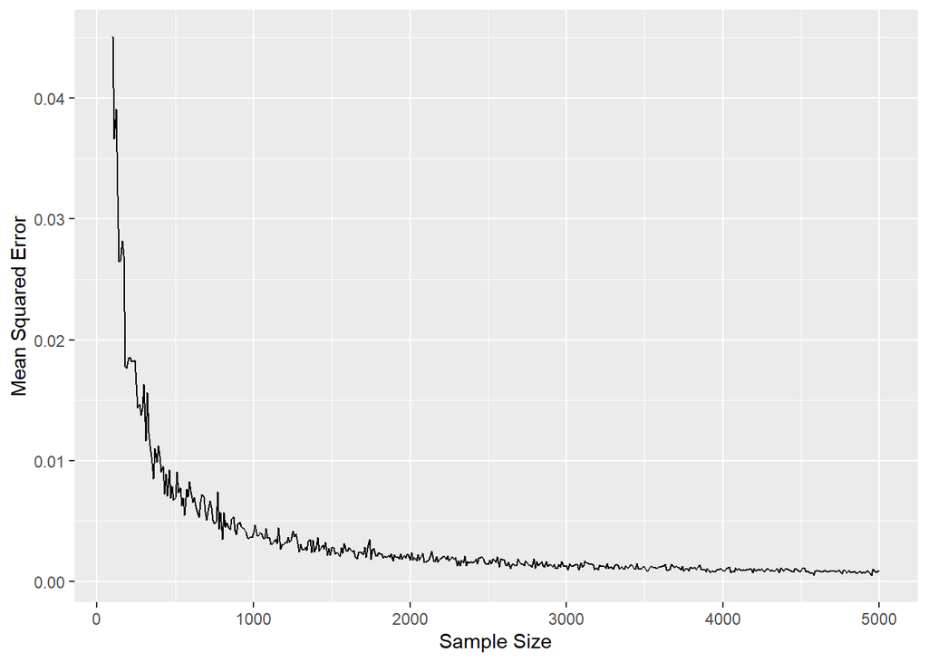

## B2

### (1) The formula for the probability mass function

The range of possible values of the discrete ranom variable $x$ is:

$$x \in\{-2,0,2\}$$

Event 1: Draw 2 blue balls $(X=-2)$

$$\begin{aligned}
& C(b, 2)=\frac{b(b-1)}{2}, C(a+b, 2)=\frac{(a+b)(a+b-1)}{2} \\
& \therefore P(x=-2)=\frac{C(b, 2)}{C(a+b,
2)}=\frac{b(b-1)}{(a+b)(a+b-1)}
\end{aligned}$$

Event 2: Draw 1 red ball and 1 blue ball $(x=0)$

$$\begin{aligned}
& C(a, 1) \cdot C(b, 1)+C(b, 1) \cdot C(a, 1)=2 \cdot a \cdot b \\
\therefore & P(X=0)=\frac{C(a, 1) C(b, 1)+C(b, 1) C(a, 1)}{C(a+b,
2)}\\
&=\frac{2 a b}{(a+b)(a+b-1)}
\end{aligned}$$

Event 3: Draw 2 red balls $(x=2)$

$$\begin{aligned}
C(a, 2) & =\frac{a(a-1)}{2} \\
\therefore P(x=2) & =\frac{C(a, 2)}{C(a+b,
2)}=\frac{a(a-1)}{(a+b)(a+b-1)}
\end{aligned}$$

### In conclustion, the formula for the probability mass function pros:

$$P(x)= \begin{cases}\frac{b(b-1)}{(a+b)(a+b-1)} & , x=-2 \\ \frac{2a
b}{(a+b)(a+b-1)} & , x=0 \\ \frac{a(a-1)}{(a+b)(a+b-1)} & ,
x=2\end{cases}$$

### (2) The expression of the expectation

According to the expectation formula for random variables:

$$\begin{equation*}
E(X)=\sum_{x \in\{-2,0,2\}} x \cdot P(X=x) \tag{1}
\end{equation*}$$

Replacing $P(x)$ into (1) , there is:

$$\begin{align*}
E(x) & =-2 \cdot \frac{b(b-1)}{(a+b)(a+b-1)}+2 \cdot
\frac{a(a-1)}{(a+b)(a+b-1)} \\
& =\frac{2 a(a-1)-2 b(b-1)}{(a+b)(a+b-1)} \\
& =\frac{2\left(a^{2}-b^{2}-a+b\right)}{(a+b)(a+b-1)} \tag{2}
\end{align*}$$

### In conclusion, the expectation $E(X)$ of $X$ is:

$$E(X)=\frac{2\left(a^{2}-b^{2}-a+b\right)}{(a+b)(a+b-1)}$$

### (3)The expression of the variance Var(X)

According to the formula of $E\left(X^{2}\right)$ :

$$\begin{equation*}
E\left(X^{2}\right)=\sum_{x \in\{-2,0,2\}} x^{2} \cdot P(X=x) \tag{1}
\end{equation*}$$

Replacing $P(x)$ in to $(1)$, there is:

$$\begin{align*}
E\left(x^{2}\right) & =4 \cdot \frac{b(b-1)}{(a+b)(a+b-1)}+4 \cdot
\frac{a(a-1)}{(a+b)(a+b-1)} \\
& =\frac{4\left(a^{2}+b^{2}-a-b\right)}{(a+b)(a+b-1)} \tag{2}
\end{align*}$$

According to the formula of $\operatorname{Var}(X)$ :

$$\begin{equation*}
\operatorname{Var}(x)=E\left(x^{2}\right)-[E(x)]^{2} \tag{3}
\end{equation*}$$

Replacing $E\left(x^{2}\right)$ and $E(x)$ into (3), it follows that:

$$\begin{aligned}
\operatorname{Var}(x) &
=\frac{4\left(a^{2}+b^{2}-a-b\right)}{(a+b)(a+b-1)}-\left[\frac{2\left(a^{2}-b^{2}-a+b\right)}{(a+b)(a+b-1)}\right]^{2}
\\
&
=\frac{4\left(a^{2}+b^{2}-a-b\right)(a+b)(a+b-1)-4\left(a^{2}-b^{2}-a+b\right)^{2}}{(a+b)^{2}(a+b-1)^{2}}
\end{aligned}$$
### In conclusion, the expression of the variance Var(X) is:
$$\begin{aligned}
\operatorname{Var}(x) &
=\frac{4\left(a^{2}+b^{2}-a-b\right)(a+b)(a+b-1)-4\left(a^{2}-b^{2}-a+b\right)^{2}}{(a+b)^{2}(a+b-1)^{2}}
\end{aligned}$$
### (4)Write a function called compute_expectation_X that takes a and b as inputs and outputs the expectation E(X). Write a function called compute_variance_X that takes a and b as input and outputs the variance Var(X).

### (5) The expression of the expectation of the random variable X

According to the linear nature of the mean of a random variable:

$$\begin{equation*}
E(\bar{X})=E\left(\frac{1}{n} \sum_{i=1}^{n} X_{i}\right)=\frac{1}{n}
\sum_{i=1}^{n} E\left(X_{i}\right) \tag{1}
\end{equation*}$$

$\because X_{i}$ are i.i.d., thus $E\left(X_{i}\right)=E(x)$, thus:

$$\begin{equation*}
E(\bar{X})=\frac{1}{n} \cdot n \cdot E(X)=E(X) \tag{2}
\end{equation*}$$

### In conclusion, the expression of the expectation of the random variable $\bar{x}$ is: $E(\bar{X})=\frac{2\left(a^{2}-b^{2}-a+b\right)}{(a+b)(a+b-1)}$

### (6) The expression of the variance of the random variable X

Considering the effect of a linear transformation of a random variable on the variance :

$$\begin{equation*}
\operatorname{Var}(a X+b)=a^{2} \operatorname{Var}(X) \tag{1}\\
\end{equation*}$$
thus:
$$\begin{align*}
&\operatorname{Var}(\bar{X})=\operatorname{Var}\left(\frac{1}{n}
\sum_{i=1}^{n} X_{i}\right) \\
&=\frac{1}{n^{2}} \operatorname{Var}\left(\sum_{i=1}^{n}
X_{i}\right) \\
&=\frac{1}{n^{2}} \cdot n \operatorname{Var}(X) \\
&=\frac{1}{n} \operatorname{Var}(X) \tag{2}
\end{align*}$$

### In conclusion, the expression of the variance of the random variable $\bar{X}$ is

$$\operatorname{Var}(\bar{X})=\frac{4\left(a^{2}+b^{2}-a-b\right)(a+b)(a+b-1)-4\left(a^{2}-b^{2}-a+b\right)^{2}}{n(a+b)^{2}(a+b-1)^{2}}$$
### (7) Create a function called sample_Xs

### (8) Calculate E(X),Var(X),E({X}),Var({X})

```
## [1] "Expectation E(X): -0.5 \n"
```

```
## [1] "Expectation of samples E(bar{X}): -0.501 \n"
```

```
## [1] "Variance Var(X): 1.60714285714286 \n"
```

```
## [1] "Variance of samples Var(bar{X}): 1.60309503095031 \n"
```

### (9) Compute the corresponding sample mean X based on X1, · · · , Xn

### (10) Create a scatter plot of the points

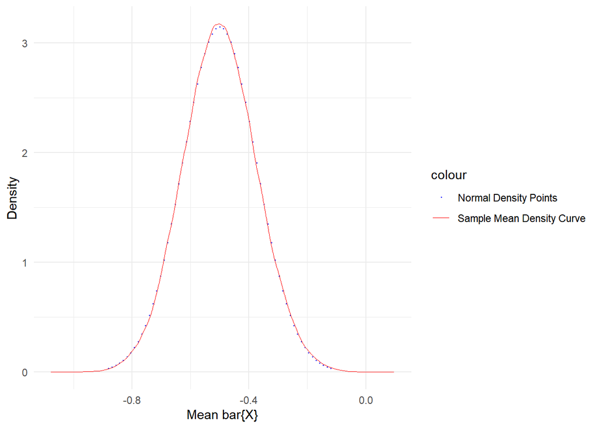